# Eighth Week: Text Analysis in R

To be, or not to be

Amirabbas Jalali 93105556

2018-05-07 23:17:13

> با استفاده از بسته gutenberg داده های لازم را به دست آورید و به سوالات زیر پاسخ دهید.

داده ها و کتابخانه های زیر در طول تمرین مورد استفاده قرارخواهندگرفت.  
برای کتاب های چالرز دیکنز یک بار تمامی کتاب های او از کتابخانه ی گوتنبرگ استخراج شد و شناسه مربوط به رمان های وی استخراج شد که در زیر می بینید.

```r
library(gutenbergr)
library(dplyr)
library(ggplot2)
library(stringr)
library(tidytext)
library(highcharter)
library(wordcloud2)

d_books_g = gutenberg_works(author == "Dickens, Charles")
d_books = c(580,730,967,700,917,968,821,766,1023,786,963,98,1400,883,564)
d_books_title = d_books_g %>%
  filter(gutenberg_id %in% d_books) %>%
  select(title,gutenberg_id)
```

```r
books_texts = list()
for(i in 1:length(d_books)){
  book = gutenberg_download(d_books[i])
  books_texts[[i]] = book
}

saveRDS(books_texts, file='data/bookstext.rds')
```

۱. چارلز دیکنز نویسنده معروف انگلیسی بالغ بر چهارده رمان (چهارده و نیم) نوشته است. متن تمامی کتاب های او را دانلود کنید و سپس بیست لغت برتر استفاده شده را به صورت یک نمودار ستونی نمایش دهید. (طبیعتا باید ابتدا متن را پاکسازی کرده و stopping words را حذف نمایید تا به کلماتی که بار معنایی مشخصی منتقل می کنند برسید.)

```r
books_texts = readRDS(file='data/bookstext.rds')

all_books_words = list()
for(i in 1:length(d_books)){
  book = books_texts[[i]]
  words = book %>%
    mutate(text = str_to_lower(text)) %>%
    select(text) %>%
    str_replace_all('\"','') %>%
    str_replace_all('=','') %>%
    str_replace_all('==','') %>%
    str_replace_all('[[:punct:]]','') %>%
    str_split(pattern = '\\s') %>%
    unlist()
  words = as.data.frame(words, stringsAsFactors = FALSE)
    if(i == 1){
      all_books_words = words
    } else {
      all_books_words = bind_rows(all_books_words, words)
    }
}

all_books_words = as.data.frame(all_books_words %>% table(dnn = list('word')),responseName = 'freq' ,stringsAsFactors = FALSE)

all_books_words = all_books_words %>%
    filter(!word %in% stop_words$word & str_length(word)>1 & !str_detect(word,'\\d')) %>%
    arrange(desc(freq))

top_20_freq = all_books_words %>% slice(1:20)

top_20_freq %>%
  hchart(type = 'column',hcaes(x = word, y = freq)) %>%
  hc_title(text = 'Most Frequent Words') %>%
  hc_yAxis(title = list(text = 'Frequency')) %>%
  hc_xAxis(title = list(text = 'Word'))
```

[interactive chart not shown]

جواب:  
نمودار لغات پرتکرار را بعد از تمیزکردن متن از علائم نگارشی و لغات ربط رسم کرده ام.

۲. ابر لغات ۲۰۰ کلمه پرتکرار در رمان های چارلز دیکنز را رسم نمایید. این کار را با بسته wordcloud2 انجام دهید. برای دانلود می توانید به لینک زیر مراجعه کنید.

https://github.com/Lchiffon/wordcloud2

```r
word_2_cloud = all_books_words[1:800,]
wordcloud2(word_2_cloud , figPath = 'images/dickens1_1.png' ,size = 0.4, color = "black")
```

[interactive chart not shown]

جواب:  
از کتابخانه ی wordcloud2 بهره گرفته ام و داده های سوال قبل را روی عکس زیر پیاده کردم.

۳. اسم پنج شخصیت اصلی در هر رمان دیکنز را استخراج کنید و با نموداری تعداد دفعات تکرار شده بر حسب رمان را رسم نمایید. (مانند مثال کلاس در رسم اسامی شخصیت ها در سری هر پاتر)

```r
book_chars = list()
for(i in 1:length(d_books)){
  book = books_texts[[i]]
  words = as.data.frame(table(book %>%
                                str_replace_all('\"','') %>%
                                str_replace_all('=','') %>%
                                str_replace_all('==','') %>%
                                str_replace_all('[[:punct:]]','') %>%
                                str_split(pattern = '\\s') %>%
                                unlist(), dnn = list('word')), responseName = "freq" )

  x = d_books_title %>% filter(gutenberg_id == d_books[i])

  chars = words %>%
    filter(!str_to_lower(word) %in% stop_words$word & str_length(word)>1 & !str_detect(word,"\\d") & !str_detect(word,"Sir"), !str_detect(word,"Miss")) %>%
    arrange(desc(freq)) %>%
    mutate(is_char_name = !word %in% str_to_lower(word), book_title = x$title) %>%
    filter(is_char_name == TRUE) %>%
    select(char = word, freq, title = book_title)

  book_chars[[i]] = chars
}

book_chars = bind_rows(book_chars)
top_5_book_chars = book_chars %>%
  group_by(title) %>%
  arrange(-freq) %>%
  slice(1:5) %>%
  ungroup()

hchart(top_5_book_chars, type = 'column', hcaes(x = char, y = freq, group = title)) %>%
  hc_title(text = 'Most Frequent Characters in Dickens\'s Novels') %>%
  hc_yAxis(title = list(text = 'Frequency')) %>%
  hc_xAxis(title = list(text = 'Character'))
```

[interactive chart not shown]

جواب:  
برای بدست آوردن اسامی شخصیت ها لغاتی را استخراج کردم که همواره با حروف بزرگ شروع می شدند و در متن با حرف کوچک این آن یافت نمی شد. تمیزکاری داده ها را همانند قبل انجام داده ام. این نمودار برحسب کتاب گروه بندی شده است و نام های مانند Tom در دو کتاب وجوددارند که جابجایی رنگ ها به همین علت است.

```r
n_p = sentiments %>%
  filter(sentiment == 'positive' | sentiment == 'negative') %>%
  select(word, sentiment)

sen_freq = all_books_words %>%
  mutate(NP = ifelse(word %in% n_p$word,1,0)) %>%
  filter(NP == 1) %>%
  select(word, freq)

selected_np = n_p %>%
  filter(word %in% sen_freq$word) %>%
  distinct(.) %>%
  mutate(sentiment = ifelse(sentiment == 'positive', 1,-1)) %>%
  group_by(word) %>%
  summarise(sentiment = mean(sentiment))

sen_freq = merge(sen_freq,selected_np)

x = sen_freq %>%
  filter(sentiment == 1) %>%
  mutate(sentiment = 'positive') %>%
  arrange(-freq) %>%
  slice(1:20)

y = sen_freq %>%
  filter(sentiment == -1) %>%
  mutate(sentiment = 'negative') %>%
  arrange(-freq) %>%
  slice(1:20)

b = bind_rows(x,y)

hchart(b, 'column', hcaes(x = word, y = freq, group = sentiment)) %>%
  hc_title(text = 'Most Frequent positive and negative words in Dickens\'s Novels') %>%
  hc_yAxis(title = list(text = 'Frequency')) %>%
  hc_xAxis(title = list(text = 'word'))
```

[interactive chart not shown]

```r
book_sentiment = list()
for(i in 1:length(d_books)){
  book = books_texts[[i]]
  words = as.data.frame(table(book %>%
                                str_replace_all('\"','') %>%
                                str_replace_all('=','') %>%
                                str_replace_all('==','') %>%
                                str_replace_all('[[:punct:]]','') %>%
                                str_split(pattern = '\\s') %>%
                                unlist(), dnn = list('word')), responseName = "freq" )

  x = d_books_title %>% filter(gutenberg_id == d_books[i])

  w = words %>%
    filter(!str_to_lower(word) %in% stop_words$word & str_length(word)>1 & !str_detect(word,"\\d") & !str_detect(word,"Sir"), !str_detect(word,"Miss")) %>%
    arrange(desc(freq)) %>%
    mutate(book_title = x$title) %>%
    select(word, freq, title = book_title)

  book_sentiment[[i]] = w
}

book_sentiment = bind_rows(book_sentiment)

book_sent_title_pos = book_sentiment %>%
  group_by(title) %>%
  merge(n_p, by = 'word') %>%
  ungroup() %>%
  group_by(title) %>%
  arrange(-freq) %>%
  filter(sentiment == 'positive') %>%
  slice(1:20)

book_sent_title_neg = book_sentiment %>%
  group_by(title) %>%
  merge(n_p, by = 'word') %>%
  ungroup() %>%
  group_by(title) %>%
  arrange(-freq) %>%
  filter(sentiment == 'negative') %>%
  slice(1:20)

book_sent_title = bind_rows(book_sent_title_neg,book_sent_title_pos)

hchart(book_sent_title, type = 'column', hcaes(x = word, y = freq, group = title, color = sentiment)) %>%
  hc_title(text = 'Most Frequent positive (yellow) and negative (purple) words in Dickens\'s Novels') %>%
  hc_yAxis(title = list(text = 'Frequency')) %>%
  hc_xAxis(title = list(text = 'Word'))
```

[interactive chart not shown]

جواب:  
این نمودار به صورت جمعی بار منفی و مثبت لغات را بررسی میکند. لغات با بار منفی به رنگ بنفش و لغات با بار مثبت به رنگ زرد مشخص شده اند. می توان از لجند موجود در پایین صفحه برای مشاهده ی یک کتاب بهره برد. نمودار کلی نیز در ابتدا رسم شده است.

۵. متن داستان بینوایان را به ۲۰۰ قسمت مساوی تقسیم کنید. برای هر قسمت تعداد لغات positive و negative را حساب کنید و سپس این دو سری زمانی را در کنار هم برای مشاهده فضای احساسی داستان رسم نمایید.

```r
v_books_g = gutenberg_works(author == "Hugo, Victor")
lesmis_id = c(48731,48732,48733,48734,48735)
v_books_title = v_books_g %>%
  filter(gutenberg_id %in% lesmis_id) %>%
  select(title,gutenberg_id)
```

```r
lesmis_texts = list()
for( i in 1:length(lesmis_id)){
  book = gutenberg_download(lesmis_id[i])
  lesmis_texts[[i]] = book
}

saveRDS(lesmis_texts, file='data/lesmis_texts.rds')
```

```r
lesmis_texts = readRDS(file='data/lesmis_texts.rds')

for(i in 1:length(lesmis_id)){
  book = lesmis_texts[[i]]
  word = book %>%
    mutate(text = str_to_lower(text)) %>%
    select(text) %>%
    str_replace_all('\"','') %>%
    str_replace_all('\"\"','') %>%
    str_replace_all('=','') %>%
    str_replace_all('==','') %>%
    str_replace_all('[[:punct:]]','') %>%
    str_split(pattern = '\\s') %>%
    unlist()

  word = as.data.frame(word, stringsAsFactors = FALSE)

    if(i == 1){
      lesmis_words = word
    } else {
      lesmis_words = bind_rows(lesmis_words, word)
    }
}

chunks = split(lesmis_words, rep(1:200,each=2743))

story_mood = list()
for(i in 1:200){
    chunk = chunks[[i]]
    chunk = chunk %>%
      group_by(word) %>%
      summarise(freq = n()) %>%
      filter(!word %in% stop_words$word & str_length(word)>1 & !str_detect(word,'\\d'))
    mood = merge(chunk,n_p, by = 'word')
    mood = mood %>%
      mutate(sentiment = ifelse(sentiment == 'positive',1,-1), score = freq*sentiment) %>%
      summarise(sum(score))
    story_mood[i] = mood[1][[1]]
}

s_m = data.frame(chunk=integer(200),
                 mood=integer(200),
                 stringsAsFactors=FALSE)

s_m$mood = story_mood
s_m$chunk = 1:200

hchart(s_m,'line', hcaes(x = chunk, y = mood)) %>%
  hc_title(text = 'Story Mood') %>%
  hc_yAxis(title = list(text = 'Mood')) %>%
  hc_xAxis(title = list(text = 'Chunk'))
```

[interactive chart not shown]

جواب:  
بعد از استخراج بار لغات به آن ها مقادیر +۱ و -۱ را نسبت دادم و مجموع آن ها را برای هر قسمت محاسبه کردم و آن را در نمودار خطی رسم کرده ام. به طور کلی فضای داستان حاوی لغات اکثرا منفی است.

۶. ابتدا ترکیبات دوتایی کلماتی که پشت سر هم می آیند را استخراج کنید و سپس نمودار ۳۰ جفت لغت پرتکرار را رسم نمایید.

```r
library(stopwords)
sw = stopwords('fr')
lesmis_words_6 = lesmis_words %>%
  filter(!word %in% sw & !word %in% stop_words$word & str_length(word)>1 & !str_detect(word,'\\d') & !str_detect(word,'chapter'))

lesmis_words_e = lesmis_words_6 %>%
  mutate(id = 1:nrow(lesmis_words_6), sp = id%%2) %>%
  filter(sp == 0) %>%
  select(word)

lesmis_words_o = lesmis_words_6 %>%
  mutate(id = 1:nrow(lesmis_words_6), sp = id%%2) %>%
  filter(sp == 1) %>%
  select(word)

pair_les_word_1 = bind_cols(lesmis_words_e,lesmis_words_o)

lesmis_words_o = lesmis_words_o %>%
  filter(row_number() != 1)

lesmis_words_e = lesmis_words_e %>%
  filter(row_number() != 94554)

pair_les_word_2 = bind_cols(lesmis_words_o,lesmis_words_e)

pair_les_word = bind_rows(pair_les_word_1,pair_les_word_2)
top_30_pair = pair_les_word %>%
  group_by(word,word1) %>%
  summarise(freq = n()) %>%
  ungroup() %>%
  arrange(-freq) %>%
  slice(1:30) %>%
  mutate(name = paste(word1,word, sep = ','))

hchart(top_30_pair, 'column', hcaes(x = name, y = freq)) %>%
  hc_title(text = 'Top 30 Most Frequent Pair words') %>%
  hc_yAxis(title = list(text = 'Frequency')) %>%
  hc_xAxis(title = list(text = 'Word'))
```

[interactive chart not shown]

جواب:  
برای بدست آوردن جفت کلمات لغات با شماره ردیف زوج و فرد و هم به صورت فرد بعدی به همراه زوج بعدی استخراج شدند و لغات ربط حذف شد و نتیجه در نمودار پیاده شد.

۷. جفت کلماتی که با she و یا he آغاز می شوند را استخراج کنید. بیست فعل پرتکراری که زنان و مردان در داستان های دیکنز انجام می دهند را استخراج کنید و نمودار آن را رسم نمایید.

```r
lesmis_words_7 = lesmis_words %>%
  filter(str_length(word)>1 & !str_detect(word,'\\d'))

lesmis_words_e = lesmis_words %>%
  mutate(id = 1:nrow(lesmis_words), sp = id%%2) %>%
  filter(sp == 0) %>%
  select(word)

lesmis_words_o = lesmis_words %>%
  mutate(id = 1:nrow(lesmis_words), sp = id%%2) %>%
  filter(sp == 1, id != 274213) %>%
  select(word)

lesmis_action = bind_cols(lesmis_words_o,lesmis_words_e)

lesmis_action_he = lesmis_action %>%
  filter(word == 'he', !word1 %in% sw, !word1 %in% stop_words$word) %>%
  mutate(action = paste(word,word1, sep = ' ')) %>%
  group_by(action) %>%
  summarise(freq = n()) %>%
  ungroup() %>%
  arrange(-freq) %>%
  slice(2:21)

hchart(lesmis_action_he, 'column', hcaes(x = action, y = freq)) %>%
  hc_title(text = 'Top 30 Most Frequent Men Actions') %>%
  hc_yAxis(title = list(text = 'Frequency')) %>%
  hc_xAxis(title = list(text = 'Action'))
```

[interactive chart not shown]

```r
lesmis_action_she = lesmis_action %>%
  filter(word == 'she', !word1 %in% sw, !word1 %in% stop_words$word) %>%
  mutate(action = paste(word,word1, sep = ' ')) %>%
  group_by(action) %>%
  summarise(freq = n()) %>%
  ungroup() %>%
  arrange(-freq) %>%
  slice(2:21)

hchart(lesmis_action_she, 'column', hcaes(x = action, y = freq)) %>%
  hc_title(text = 'Top 30 Most Frequent Women Actions') %>%
  hc_yAxis(title = list(text = 'Frequency')) %>%
  hc_xAxis(title = list(text = 'Action'))
```

[interactive chart not shown]

جواب:  
برای این کار همانند سوال قبل عمل کرده و با این تفاوت که برای he و she لغات بعدی آن ها را بعد از تمیزکاری در نظر گرفته ام و شمارش آن ها را در نظر گرفتم و آن را در نمودار کشیده ام.

۸. برای کتاب های دیکنز ابتدا هر فصل را جدا کنید. سپی برای هر فصل 1-gram, 2-gram را استخراج کنید. آیا توزیع N-gram در کارهای دیکنز یکسان است؟ با رسم نمودار هم این موضوع را بررسی کنید.

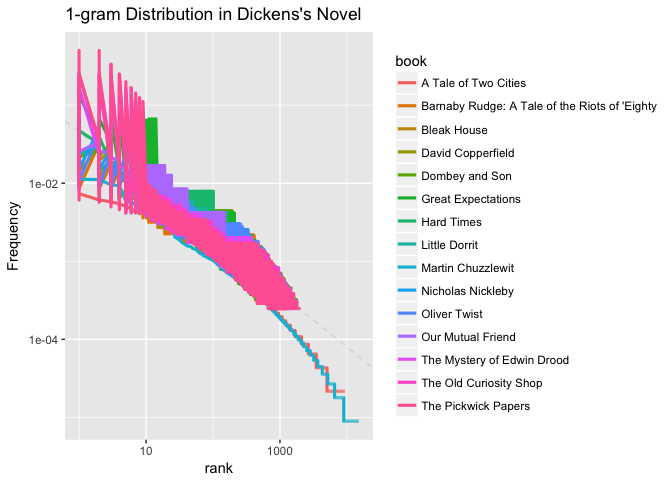

```r
d_ngm_1 = list()
for(i in 1:length(d_books)){
  book = books_texts[[i]]
  x = d_books_title %>% filter(gutenberg_id == d_books[i])
  wbook = book %>% mutate(linenumber = row_number(),
                          chapter = cumsum(str_detect(text, regex("^chapter [\\divxlc]+",
                                                                  ignore_case = TRUE)))) %>%
    filter(text != "") %>%
    unnest_tokens(bigram, text, token = "ngrams", n = 1) %>%
    mutate(book = x$title)
  d_ngm_1[[i]] = wbook
}

d_ngm_books_1 = bind_rows(d_ngm_1)

d_ngm_1_freq = d_ngm_books_1 %>%
  filter(!bigram %in% stop_words$word) %>%
  group_by(book ,chapter) %>%
  mutate(total_words = n()) %>%
  ungroup() %>%
  group_by(book ,chapter, bigram) %>%
  mutate(freq = n()) %>%
  mutate(tf = freq/total_words) %>%
  summarise(freq = mean(freq), tf = mean(tf)) %>%
  ungroup() %>%
  group_by(book, chapter) %>%
  arrange(-freq) %>%
  mutate(rank = row_number())

coefi = lm(log10(tf) ~ log10(rank), data = d_ngm_1_freq)
ggplot(d_ngm_1_freq, aes(rank, tf, color = book)) +
  geom_abline(intercept = coefi$coefficients[1], slope = coefi$coefficients[2], color = "gray85", linetype = 2) +
  geom_line(size = 1.1, alpha = 1) +
  ylab("Frequency") +
  ggtitle("1-gram Distribution in Dickens\'s Novel") +
  scale_x_log10() +
  scale_y_log10()
```

[figure not shown]

```r
d_ngm_2 = list()
for(i in 1:length(d_books)){
  book = books_texts[[i]]
  x = d_books_title %>% filter(gutenberg_id == d_books[i])
  wbook = book %>% mutate(linenumber = row_number(),
                          chapter = cumsum(str_detect(text, regex("^chapter [\\divxlc]+",
                                                                  ignore_case = TRUE)))) %>%
    filter(text != "") %>%
    unnest_tokens(bigram, text, token = "ngrams", n = 2) %>%
    mutate(book = x$title)
  d_ngm_2[[i]] = wbook
}

d_ngm_books_2 = bind_rows(d_ngm_2)

d_ngm_2_freq = d_ngm_books_2 %>%
  filter(!bigram %in% stop_words$word) %>%
  group_by(book ,chapter) %>%
  mutate(total_words = n()) %>%
  ungroup() %>%
  group_by(book ,chapter, bigram) %>%
  mutate(freq = n()) %>%
  mutate(tf = freq/total_words) %>%
  summarise(freq = mean(freq), tf = mean(tf)) %>%
  ungroup() %>%
  group_by(book, chapter) %>%
  arrange(-freq) %>%
  mutate(rank = row_number())

coefi = lm(log10(tf) ~ log10(rank), data = d_ngm_2_freq)
ggplot(d_ngm_1_freq, aes(rank, tf, color = book)) +
  geom_abline(intercept = coefi$coefficients[1], slope = coefi$coefficients[2], color = "gray85", linetype = 2) +
  geom_line(size = 1.1, alpha = 1) +
  ylab("Frequency") +
  ggtitle("2-gram Distribution in Dickens\'s Novel") +
  scale_x_log10() +
  scale_y_log10()
```

۹. برای آثار ارنست همینگوی نیز تمرین ۸ را تکرار کنید. آیا بین آثار توزیع n-grams در بین آثار این دو نویسنده یکسان است؟

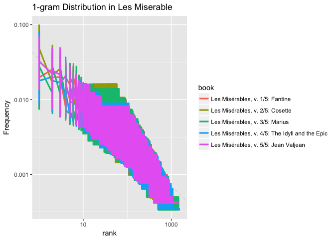

```r
v_ngm_1 = list()
for(i in 1:length(lesmis_id)){
  book = lesmis_texts[[i]]
  x = v_books_title %>% filter(gutenberg_id == lesmis_id[i])
  wbook = book %>% mutate(linenumber = row_number(),
                          chapter = cumsum(str_detect(text, regex("^chapter [\\divxlc]+",
                                                                  ignore_case = TRUE)))) %>%
    filter(text != "") %>%
    mutate(book = x$title) %>%
    unnest_tokens(bigram, text, token = "ngrams", n = 1)
  v_ngm_1[[i]] = wbook
}

v_ngm_books_1 = bind_rows(v_ngm_1)

v_ngm_1_freq = v_ngm_books_1 %>%
  filter(!bigram %in% stop_words$word) %>%
  group_by(book ,chapter) %>%
  mutate(total_words = n()) %>%
  ungroup() %>%
  group_by(book ,chapter, bigram) %>%
  mutate(freq = n()) %>%
  mutate(tf = freq/total_words) %>%
  summarise(freq = mean(freq), tf = mean(tf)) %>%
  ungroup() %>%
  group_by(book, chapter) %>%
  arrange(-freq) %>%
  mutate(rank = row_number())

coefi = lm(log10(tf) ~ log10(rank), data = v_ngm_1_freq)
ggplot(v_ngm_1_freq, aes(rank, tf, color = book)) +
  geom_abline(intercept = coefi$coefficients[1], slope = coefi$coefficients[2], color = "gray85", linetype = 2) +
  geom_line(size = 1.1, alpha = 1) +
  ylab("Frequency") +
  ggtitle("1-gram Distribution in Les Miserable") +
  scale_x_log10() +
  scale_y_log10()
```

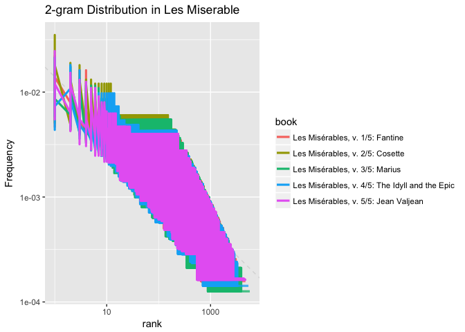

```r
v_ngm_2 = list()
for(i in 1:length(lesmis_id)){
  book = lesmis_texts[[i]]
  x = v_books_title %>% filter(gutenberg_id == lesmis_id[i])
  wbook = book %>% mutate(linenumber = row_number(),
                          chapter = cumsum(str_detect(text, regex("^chapter [\\divxlc]+",
                                                                  ignore_case = TRUE)))) %>%
    filter(text != "") %>%
    mutate(book = x$title) %>%
    unnest_tokens(bigram, text, token = "ngrams", n = 2)
  v_ngm_2[[i]] = wbook
}

v_ngm_books_2 = bind_rows(v_ngm_2)

v_ngm_2_freq = v_ngm_books_2 %>%
  filter(!bigram %in% stop_words$word) %>%
  group_by(book ,chapter) %>%
  mutate(total_words = n()) %>%
  ungroup() %>%
  group_by(book ,chapter, bigram) %>%
  mutate(freq = n()) %>%
  mutate(tf = freq/total_words) %>%
  summarise(freq = mean(freq), tf = mean(tf)) %>%
  ungroup() %>%
  group_by(book, chapter) %>%
  arrange(-freq) %>%
  mutate(rank = row_number())

coefi = lm(log10(tf) ~ log10(rank), data = v_ngm_2_freq)
ggplot(v_ngm_2_freq, aes(rank, tf, color = book)) +
  geom_abline(intercept = coefi$coefficients[1], slope = coefi$coefficients[2], color = "gray85", linetype = 2) +
  geom_line(size = 1.1, alpha = 1) +
  ylab("Frequency") +
  ggtitle("2-gram Distribution in Les Miserable") +
  scale_x_log10() +
  scale_y_log10()
```

جواب:  
همانند سوال قبل برای کتاب بینوایان ویکتورهوگو نیز صورت گرفت که نتیجه قابل مشاهده است. از بقیه کتاب های این نویسنده صرف نظرشده است. این نمودار نیز مانند دو نمودار سوال قبل شباهت هایی را در این آثار نشان می دهد.

۱۰. بر اساس دادهایی که در تمرین ۸ و ۹ از آثار دو نویسنده به دست آوردید و با استفاده از N-gram ها یک مدل لاجستیک برای تشخیص صاحب اثر بسازید. خطای مدل چقدر است؟ برای یادگیری مدل از کتاب کتاب الیور تویست اثر دیکنز و کتاب پیرمرد و دریا استفاده نکنید. پس از ساختن مدل برای تست کردن فصل های این کتابها را به عنوان داده ورودی به مدل بدهید. خطای تشخیص چقدر است؟

```r
v_train = v_ngm_1_freq %>%
  select(bigram, freq) %>%
  mutate(author = 0) %>%
  filter(freq > 30)

d_train = d_ngm_1_freq %>%
  filter(book != 'Oliver Twist') %>%
  select(bigram, freq) %>%
  mutate(author = 1) %>%
  filter(freq > 30)

train = bind_rows(d_train, v_train)

lm = glm(author~bigram*freq,family = binomial(link = 'logit'), data = train)
summary(lm)
```

[output not shown]

[output cut: 1895 more lines]

```
bigramworthy:freq                 NA         NA      NA       NA
bigramwrite:freq                  NA         NA      NA       NA
bigramwriting:freq                NA         NA      NA       NA
bigramwritten:freq                NA         NA      NA       NA
bigramwrong:freq                  NA         NA      NA       NA
bigramyesterday:freq              NA         NA      NA       NA
bigramyork:freq                   NA         NA      NA       NA

(Dispersion parameter for binomial family taken to be 1)

    Null deviance: 362.866  on 1852  degrees of freedom
Residual deviance:   5.012  on  578  degrees of freedom
AIC: 2555

Number of Fisher Scoring iterations: 24
```

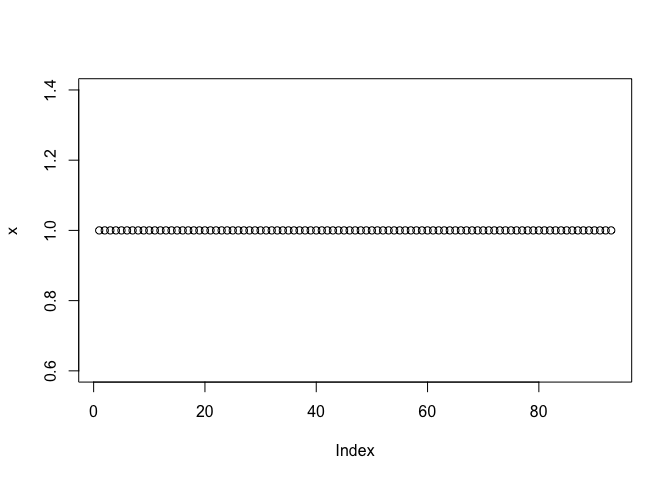

```r
test = d_ngm_1_freq %>%
  filter(book == 'Bleak House') %>%
  select(bigram, freq) %>%
  filter(freq > 30)

x = predict(lm, newdata = test, type = 'response')
plot(x)
```

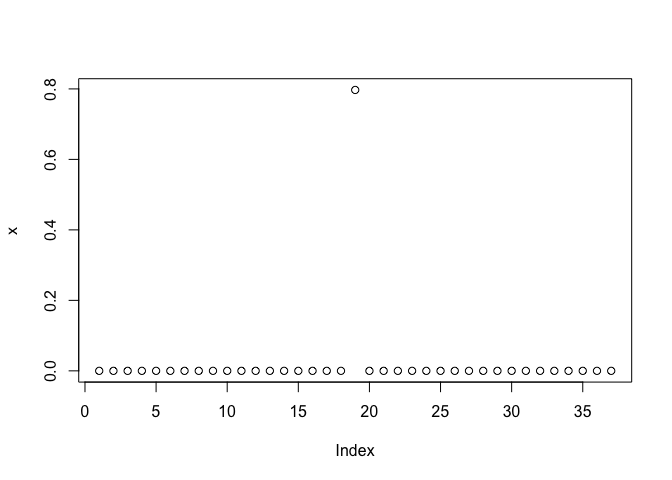

```r
test = v_ngm_1_freq %>%
  select(bigram, freq) %>%
  filter(freq > 30)

x = predict(lm, newdata = test, type = 'response')
plot(x)
```

جواب:  
با استفاده از glm این داده ها برازش یافته که برروی داده های در دسترس که با آن ها برازش نیز شده نتیجه ی مطلوبی به دست می دهد ولی مشکل اصلی همسان سازی داده ی جدید برای آزمایش است که باید هم تراز شود.